# Crime and Communities Exercise

This dataset combines socio-economic data from the 1990 US Census, law enforcement data from the 1990 US LEMAS survey, and crime data from the 1995 FBI UCR.

In this exercise, we will be comparing ridge regression, LASSO regression, and elastic net regularization. First we load the data.

```r
library(RCurl)
library(glmnet)
## get column names
# specify the URL for the column names and descriptions
names.file.url <- 'http://archive.ics.uci.edu/ml/machine-learning-databases/communities/communities.names'
names.file.lines <- readLines(names.file.url)
# only keep the attribute names, and discard the rest of the lines
names.dirtylines <- grep("@attribute ", names.file.lines, value = TRUE)
# split on spaces and pick the second word
names <- sapply(strsplit(names.dirtylines, " "), "[[", 2)
# drop the first 5 columns
names <- names[6:length(names)]
## download data and join in names
# specify the URL for the Crime and Communities data CSV
urlfile <-'http://archive.ics.uci.edu/ml/machine-learning-databases/communities/communities.data'
# download the file
downloaded <- getURL(urlfile, ssl.verifypeer=FALSE)
# treat the text data as a steam so we can read from it
connection <- textConnection(downloaded)
# parse the downloaded data as CSV
dataset <- read.csv(connection, header=FALSE, na.strings=c("?"))
# drop irrelevant columns
dataset <- dataset[ ,6:ncol(dataset)]
# drop rows with null columns
dataset <- dataset[rowSums(is.na(dataset)) == 0,]
# fix the column names
colnames(dataset) <- names
# preview the first 5 rows
head(dataset)
```

|  | population | householdsize | racepctblack | racePctWhite | racePctAsian | racePctHisp | agePct12t21 | agePct12t29 | agePct16t24 | agePct65up | numbUrban | pctUrban | medIncome | pctWWage | pctWFarmSelf | pctWInvInc | pctWSocSec | pctWPubAsst | pctWRetire | medFamInc | perCapInc | whitePerCap | blackPerCap | indianPerCap | AsianPerCap | OtherPerCap | HispPerCap | NumUnderPov | PctPopUnderPov | … |
| --- | --- | --- | --- | --- | --- | --- | --- | --- | --- | --- | --- | --- | --- | --- | --- | --- | --- | --- | --- | --- | --- | --- | --- | --- | --- | --- | --- | --- | --- | --- |
| 1 | 0.19 | 0.33 | 0.02 | 0.90 | 0.12 | 0.17 | 0.34 | 0.47 | 0.29 | 0.32 | 0.20 | 1.00 | 0.37 | 0.72 | 0.34 | 0.60 | 0.29 | 0.15 | 0.43 | 0.39 | 0.40 | 0.39 | 0.32 | 0.27 | 0.27 | 0.36 | 0.41 | 0.08 | 0.19 | … |
| 17 | 0.15 | 0.31 | 0.40 | 0.63 | 0.14 | 0.06 | 0.58 | 0.72 | 0.65 | 0.47 | 0.16 | 1.00 | 0.22 | 0.52 | 0.10 | 0.51 | 0.48 | 0.39 | 0.51 | 0.30 | 0.29 | 0.34 | 0.23 | 0.13 | 0.20 | 0.20 | 0.30 | 0.15 | 0.48 | … |
| 21 | 0.25 | 0.54 | 0.05 | 0.71 | 0.48 | 0.30 | 0.42 | 0.48 | 0.28 | 0.32 | 0.26 | 1.00 | 0.33 | 0.55 | 0.37 | 0.37 | 0.39 | 0.64 | 0.44 | 0.32 | 0.29 | 0.32 | 0.23 | 0.17 | 0.17 | 0.24 | 0.30 | 0.19 | 0.34 | … |
| 22 | 1.00 | 0.42 | 0.47 | 0.59 | 0.12 | 0.05 | 0.41 | 0.53 | 0.34 | 0.33 | 1.00 | 0.99 | 0.28 | 0.62 | 0.16 | 0.36 | 0.40 | 0.30 | 0.45 | 0.29 | 0.30 | 0.35 | 0.21 | 0.20 | 0.33 | 0.28 | 0.40 | 0.76 | 0.33 | … |
| 24 | 0.11 | 0.43 | 0.04 | 0.89 | 0.09 | 0.06 | 0.45 | 0.48 | 0.31 | 0.46 | 0.13 | 1.00 | 0.22 | 0.52 | 0.44 | 0.49 | 0.56 | 0.41 | 0.39 | 0.25 | 0.25 | 0.25 | 0.16 | 0.07 | 0.20 | 0.19 | 0.22 | 0.10 | 0.36 | … |
| 34 | 0.09 | 0.43 | 0.51 | 0.58 | 0.04 | 0.01 | 0.58 | 0.56 | 0.50 | 0.52 | 0.10 | 1.00 | 0.20 | 0.42 | 0.21 | 0.44 | 0.65 | 0.36 | 0.52 | 0.24 | 0.26 | 0.31 | 0.19 | 0.22 | 0.14 | 0.26 | 0.26 | 0.09 | 0.43 | … |

We now split this dataset into train and test sets (an alternative would be to use cross-validation).

```r
## perform train-test split
# 75% of the sample size
smp_size <- floor(0.75 * nrow(dataset))
## set the seed to make your partition reproductible
set.seed(123)
train_ind <- sample(seq_len(nrow(dataset)), size = smp_size)
df.train <- dataset[train_ind, ]
df.test <- dataset[-train_ind, ]
```

#### Q1. Fit a linear regression model on df.train. The goal is to predict ‘ViolentCrimesPerPop’ from the other columns. What is the r-squared on the train data? What about the test data?

We are going to use the `glmnet` package for this exercise (as it is helpful for the next few questions as well). `glmnet` fits an elastic net model by default. Recall that the loss function for elastic net was given by:
$$\underset{w}{\operatorname{argmin}}{\cal L}(X) + (1 - \alpha) \cdot \lambda \sum_{i=1}^M \beta_i^2 + \alpha \cdot \lambda \sum_{i=1}^M |\beta_i|.$$
Thus, for linear regression, we need to set $\lambda = 0$.

Note that this package can fit other generalized linear models as well, including logistic regression for classification, Poisson regression for modeling count data, and Cox regression for survival analysis/churn prediction. To fit these other models, you will have to change the `family` parameter in the `glmnet` function call.

For details and examples on the package, visit https://web.stanford.edu/~hastie/glmnet/glmnet_alpha.html

```r
labelColIdx = match(c("ViolentCrimesPerPop"), names)
fit.linreg <- glmnet(as.matrix(df.train[,-labelColIdx]),
                     as.matrix(df.train$ViolentCrimesPerPop),
                     alpha=1, lambda=0, family="gaussian",
                     standardize=FALSE)
fitted.linreg.train <- predict(fit.linreg, newx = data.matrix(df.train[,-labelColIdx]), s=0)
fitted.linreg.test <- predict(fit.linreg, newx = data.matrix(df.test[,-labelColIdx]), s=0)
cat("\nTrain correlation coefficient: ", cor(as.matrix(df.train$ViolentCrimesPerPop), fitted.linreg.train)[1])
```

```
Train correlation coefficient:  0.9281492
```

```r
cat("\nTest correlation coefficient: ", cor(as.matrix(df.test$ViolentCrimesPerPop), fitted.linreg.test)[1])
```

```
Test correlation coefficient:  0.6168479
```

#### Q2. Also fit each of a ridge, lasso, and elastic net regression on the same data. Use the function `cv.glmnet` to cross-validate and find the best values of $\lambda$. For elastic net, try a few values of $\alpha$ as well.

##### Hint: `cv.glmnet` does not optimize for $\alpha$. You should use the command `set.seed(k)` for some fixed `k` before each value of $\alpha$ being run. You can do the cross validation for $\alpha$ manually for the purpose of this exercise. `cv.glmnet` automatically picks appropriate values of $\lambda$ to try.

#### Q3. Which model performs the best?

#### Ridge Regression

```r
fit.ridge <- cv.glmnet(as.matrix(df.train[,-labelColIdx]),
                        as.matrix(df.train$ViolentCrimesPerPop),
                        type.measure="mse", alpha=0, family="gaussian",
                        standardize=FALSE)
fitted.ridge.train <- predict(fit.ridge,
                              newx = data.matrix(df.train[,-labelColIdx]),
                              s = "lambda.min")
fitted.ridge.test <- predict(fit.ridge,
                             newx = data.matrix(df.test[,-labelColIdx]),
                             s = "lambda.min")
cat("\nTrain correlation coefficient: ", cor(as.matrix(df.train$ViolentCrimesPerPop), fitted.ridge.train)[1])
```

```
Train correlation coefficient:  0.8463421
```

```r
cat("\nTest correlation coefficient: ", cor(as.matrix(df.test$ViolentCrimesPerPop), fitted.ridge.test)[1])
```

```
Test correlation coefficient:  0.7725274
```

#### LASSO

```r
fit.lasso <- cv.glmnet(as.matrix(df.train[,-labelColIdx]),
                        as.matrix(df.train$ViolentCrimesPerPop),
                        type.measure="mse", alpha=1, family="gaussian",
                        standardize=FALSE)
fitted.lasso.train <- predict(fit.lasso,
                              newx = data.matrix(df.train[,-labelColIdx]),
                              s = "lambda.min")
fitted.lasso.test <- predict(fit.lasso,
                             newx = data.matrix(df.test[,-labelColIdx]),
                             s = "lambda.min")
cat("\nTrain correlation coefficient: ", cor(as.matrix(df.train$ViolentCrimesPerPop), fitted.lasso.train)[1])
```

```
Train correlation coefficient:  0.8416111
```

```r
cat("\nTest correlation coefficient: ", cor(as.matrix(df.test$ViolentCrimesPerPop), fitted.lasso.test)[1])
```

```
Test correlation coefficient:  0.7647234
```

#### Elastic Net

```r
for (a in log10(seq(1,10,1))) {
  set.seed(1)
  cat("\nalpha =", a)
  fit.elastic <- cv.glmnet(as.matrix(df.train[,-labelColIdx]),
                         as.matrix(df.train$ViolentCrimesPerPop),
                         type.measure="mse", alpha=a, family="gaussian",
                         standardize=FALSE)
  fitted.elastic.train <- predict(fit.elastic,
                                  newx = data.matrix(df.train[,-labelColIdx]),
                                  s = "lambda.min")
  fitted.elastic.test <- predict(fit.elastic,
                                 newx = data.matrix(df.test[,-labelColIdx]),
                                 s = "lambda.min")
  cat("\nTrain correlation coefficient: ", cor(as.matrix(df.train$ViolentCrimesPerPop),
                                             fitted.elastic.train)[1])
  cat("\nTest correlation coefficient: ", cor(as.matrix(df.test$ViolentCrimesPerPop),
                                            fitted.elastic.test)[1])
}
```

```
alpha = 0
Train correlation coefficient:  0.8463421
Test correlation coefficient:  0.7725274
alpha = 0.30103
Train correlation coefficient:  0.8422018
Test correlation coefficient:  0.7743667
alpha = 0.4771213
Train correlation coefficient:  0.8431613
Test correlation coefficient:  0.7725671
alpha = 0.60206
Train correlation coefficient:  0.8396885
Test correlation coefficient:  0.7750139
alpha = 0.69897
Train correlation coefficient:  0.8385353
Test correlation coefficient:  0.775335
alpha = 0.7781513
Train correlation coefficient:  0.8389381
Test correlation coefficient:  0.7739676
alpha = 0.845098
Train correlation coefficient:  0.8392571
Test correlation coefficient:  0.7725298
alpha = 0.90309
Train correlation coefficient:  0.8358358
Test correlation coefficient:  0.7739304
alpha = 0.9542425
Train correlation coefficient:  0.8359402
Test correlation coefficient:  0.7711216
alpha = 1
Train correlation coefficient:  0.83583
Test correlation coefficient:  0.7687891
```

```r
optalpha <- 0.30103
fit.elastic <- cv.glmnet(as.matrix(df.train[,-labelColIdx]),
                         as.matrix(df.train$ViolentCrimesPerPop),
                         type.measure="mse", alpha=optalpha,
                         family="gaussian", standardize=FALSE)
fit.elastic2 <- cv.glmnet(as.matrix(df.train[,-labelColIdx]),
                         as.matrix(df.train$ViolentCrimesPerPop),
                         type.measure="mse", alpha=optalpha,
                         family="gaussian", standardize=TRUE)
```

#### Q4. Make the following scatterplot:

#### - Each point corresponds to one predictor in the data

#### - The x-value is the coefficient of that predictor under OLS regression

#### - The y-value is the coefficient of that predictor using ridge regularization

#### Q5. Do the same for OLS vs Lasso, and OLS vs ElasticNet. What do you notice about the magnitude of the parameters and numbers of zeros?

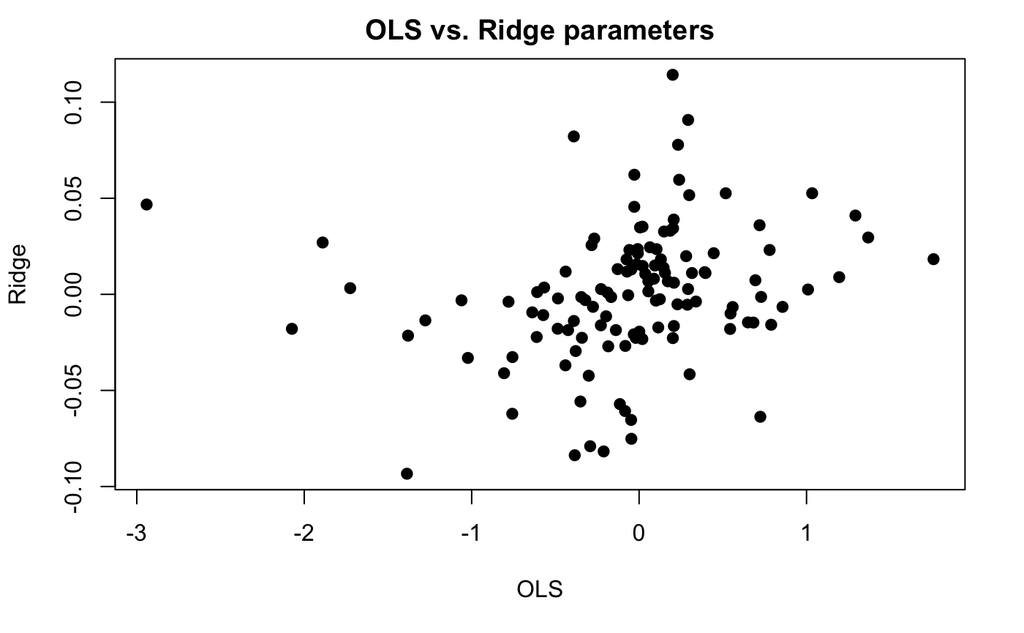

```r
plot(coef(fit.linreg, s=0)[-1], coef(fit.ridge, s=0)[-1], main="OLS vs. Ridge parameters",
    xlab="OLS", ylab="Ridge", pch=19)
```

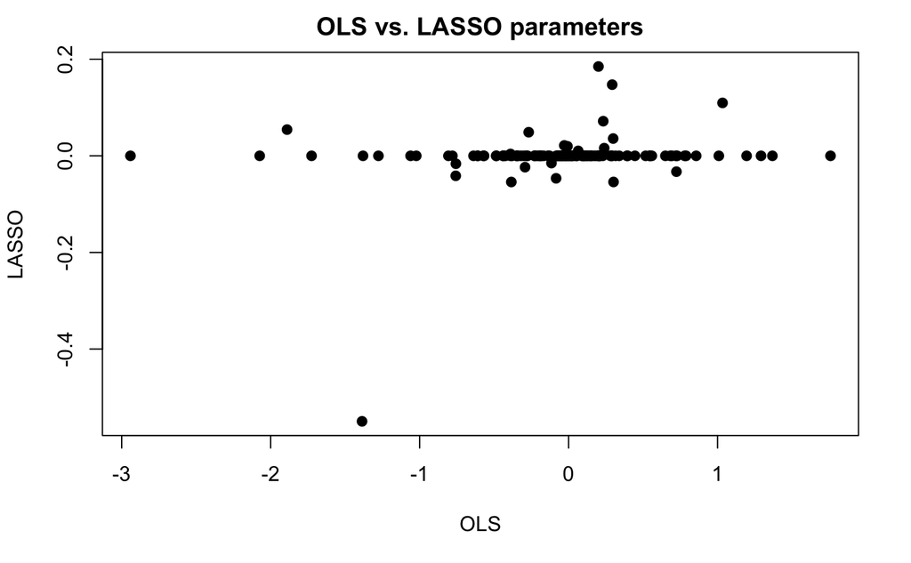

```r
plot(coef(fit.linreg, s=0)[-1], coef(fit.lasso, s="lambda.min")[-1], main="OLS vs. LASSO parameters",
    xlab="OLS", ylab="LASSO", pch=19)
```

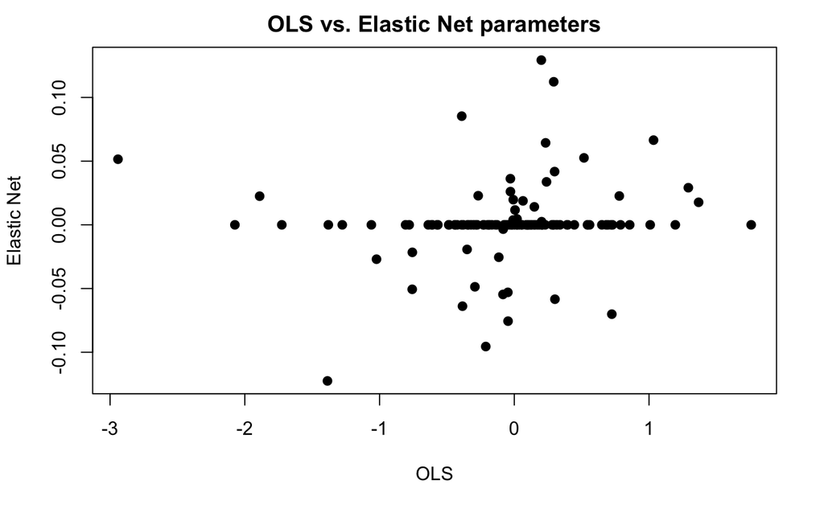

```r
plot(coef(fit.linreg, s=0)[-1], coef(fit.elastic, s="lambda.min")[-1], main="OLS vs. Elastic Net parameters",
    xlab="OLS", ylab="Elastic Net", pch=19)
```

The magnitude of the ridge regression parameters are much smaller in magnitude than those for OLS. For LASSO, many parameters are exactly zero, yielding a sparse solution. Same (but to a lesser extent) for the elastic net.

#### Q6. Make the following scatterplot:

#### - Each point corresponds to one predictor in the data

#### - The x-value is the coefficient of that predictor under OLS regression

#### - The y-value is the correlation coefficient of that predictor with the target

#### Q7. Based on the above plot, what can you say about the interpretation of the regression coefficients? Does the sign of the coefficient implying the relationship of that variable and the target? What are some potential issues interpreting the magnitude?

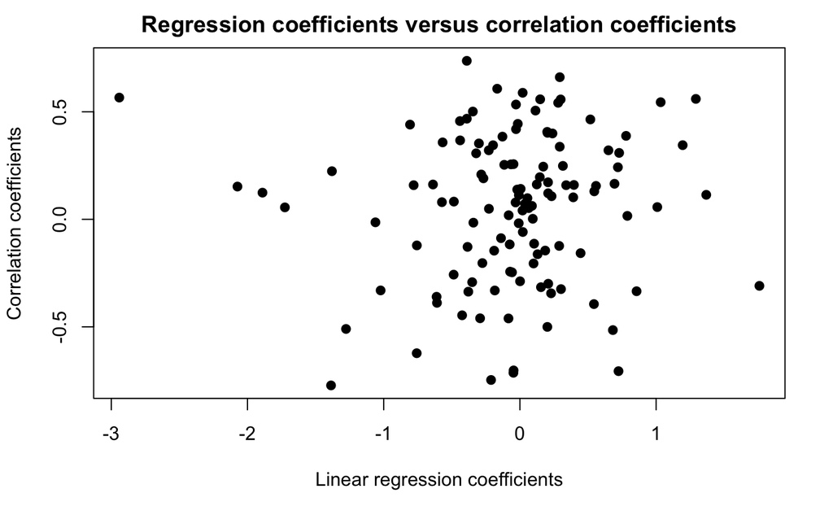

```r
# initialize with coefficient vector to keep the row names
corrs <- array(0.0,length(coef(fit.linreg, s=0)[-1]))
cnt <- 0
for (feat in rownames(coef(fit.linreg, s=0))[-1]) {
  cnt <- cnt + 1
  corrs[cnt] <- cor(as.matrix(df.train$ViolentCrimesPerPop), df.train[,feat])[1]
}
plot(coef(fit.linreg, s=0)[-1], corrs, main="Regression coefficients versus correlation coefficients",
    xlab="Linear regression coefficients", ylab="Correlation coefficients", pch=19)
```